# Working with multiple endpoints

2019-05-09

[figure not shown]

nlmixr

# Multiple endpoints

Joint PK/PD models, or PK/PD models where you fix certain components are common in pharmacometrics. A classic example, (provided by Tomoo Funaki and Nick Holford) is Warfarin.

```r
library(nlmixr)

## These options cache the models and the model simulations in R
## To run the actual models on your system, take the save options off.
options(nlmixr.save=TRUE,
        nlmixr.save.dir=system.file(package="nlmixr"));

invisible(memoise::cache_filesystem(file.path(system.file(package="nlmixr"),"memo")))
```

In this example, we have a transit-compartment (from depot to gut to central volume) PK model and an effect compartment for the PCA measurement.

Below is an illustrated example of a model that can be applied to the data:

```r
pk.turnover.emax <- function() {
  ini({
    tktr <- log(1)
    tka <- log(1)
    tcl <- log(0.1)
    tv <- log(10)
    ##
    eta.ktr ~ 1
    eta.ka ~ 1
    eta.cl ~ 2
    eta.v ~ 1
    prop.err <- 0.1
    pkadd.err <- 0.1
    ##
    poplogit <- 2
    #temax <- 7.5
    tec50 <- log(0.5)
    tkout <- log(0.05)
    te0 <- log(100)
    ##
    eta.emax ~ .5
    eta.ec50  ~ .5
    eta.kout ~ .5
    eta.e0 ~ .5
    ##
    pdadd.err <- 10
  })
  model({
    ktr <- exp(tktr + eta.ktr)
    ka <- exp(tka + eta.ka)
    cl <- exp(tcl + eta.cl)
    v <- exp(tv + eta.v)
    ##
    #poplogit = log(temax/(1-temax))
    logit=exp(poplogit+eta.emax)
    #logit=temax+eta.emax
    emax = logit/(1+logit)
    ec50 =  exp(tec50 + eta.ec50)
    kout = exp(tkout + eta.kout)
    e0 = exp(te0 + eta.e0)
    ##
    DCP = center/v
    PD=1-emax*DCP/(ec50+DCP)
    ##
    effect(0) = e0
    kin = e0*kout
    ##
    d/dt(depot) = -ktr * depot
    d/dt(gut) =  ktr * depot -ka * gut
    d/dt(center) =  ka * gut - cl / v * center
    d/dt(effect) = kin*PD -kout*effect
    ##
    cp = center / v
    cp ~ prop(prop.err) + add(pkadd.err)
    effect ~ add(pdadd.err)
  })
}
```

Notice there are two endpoints in the model `cp` and `effect`. Both are modeled in nlmixr using the `~` “modeled by” specification.

To see more about how nlmixr will handle the multiple compartment model, it is quite informative to parse the model and print the information about that model. In this case an initial parsing would give:

```r
ui <- nlmixr(pk.turnover.emax)
ui
```

```
#> ▂▂ RxODE-based ODE model ▂▂▂▂▂▂▂▂▂▂▂▂▂▂▂▂▂▂▂▂▂▂▂▂▂▂▂▂▂▂▂▂▂▂▂▂▂▂▂▂▂▂▂▂▂▂▂▂▂▂
#> ── Initialization: ────────────────────────────────────────────────────────
#> Fixed Effects ($theta):
#>       tktr        tka        tcl         tv   poplogit      tec50
#>  0.0000000  0.0000000 -2.3025851  2.3025851  2.0000000 -0.6931472
#>      tkout        te0
#> -2.9957323  4.6051702
#>
#> Omega ($omega):
#>          eta.ktr eta.ka eta.cl eta.v eta.emax eta.ec50 eta.kout eta.e0
#> eta.ktr        1      0      0     0      0.0      0.0      0.0    0.0
#> eta.ka         0      1      0     0      0.0      0.0      0.0    0.0
#> eta.cl         0      0      2     0      0.0      0.0      0.0    0.0
#> eta.v          0      0      0     1      0.0      0.0      0.0    0.0
#> eta.emax       0      0      0     0      0.5      0.0      0.0    0.0
#> eta.ec50       0      0      0     0      0.0      0.5      0.0    0.0
#> eta.kout       0      0      0     0      0.0      0.0      0.5    0.0
#> eta.e0         0      0      0     0      0.0      0.0      0.0    0.5
#> ── Multiple Endpoint Model ($multipleEndpoint): ───────────────────────────
#> ┌───────────────────────┬───────────────────────┬───────────────────────┐
#> │ variable              │ cmt                   │ dvid*                 │
#> ├───────────────────────┼───────────────────────┼───────────────────────┤
#> │ cp ~ …                │ cmt='cp' or cmt=5     │ dvid='cp' or dvid=1   │
#> ├───────────────────────┼───────────────────────┼───────────────────────┤
#> │ effect ~ …            │ cmt='effect' or cmt=4 │ dvid='effect' or      │
#> │                       │                       │ dvid=2                │
#> └───────────────────────┴───────────────────────┴───────────────────────┘
#>   * If dvids are outside this range, all dvids are re-numered
#>   sequentially, ie 1,7, 10 becomes 1,2,3 etc
#> ── μ-referencing ($muRefTable): ───────────────────────────────────────────
#> ┌──────────┬──────────┐
#> │ theta    │ eta      │
#> ├──────────┼──────────┤
#> │ tktr     │ eta.ktr  │
#> ├──────────┼──────────┤
#> │ tka      │ eta.ka   │
#> ├──────────┼──────────┤
#> │ tcl      │ eta.cl   │
#> ├──────────┼──────────┤
#> │ tv       │ eta.v    │
```

[output cut: 23 more lines]

```
#>     DCP = center/v
#>     PD=1-emax*DCP/(ec50+DCP)
#>     ##
#>     effect(0) = e0
#>     kin = e0*kout
#>     ##
#>     d/dt(depot) = -ktr * depot
#>     d/dt(gut) =  ktr * depot -ka * gut
#>     d/dt(center) =  ka * gut - cl / v * center
#>     d/dt(effect) = kin*PD -kout*effect
#>     ##
#>     cp = center / v
#>     cp ~ prop(prop.err) + add(pkadd.err)
#>     effect ~ add(pdadd.err)
#> ▂▂▂▂▂▂▂▂▂▂▂▂▂▂▂▂▂▂▂▂▂▂▂▂▂▂▂▂▂▂▂▂▂▂▂▂▂▂▂▂▂▂▂▂▂▂▂▂▂▂▂▂▂▂▂▂▂▂▂▂▂▂▂▂▂▂▂▂▂▂▂▂▂▂▂
```

In the middle of the printout, it shows how the data must be formatted (using the `cmt` and `dvid` data items) to allow nlmixr to model the multiple endpoint appropriately.

Of course if you are interested you can directly access the information in `ui$multipleEndpoint`.

```r
ui$multipleEndpoint
```

| variable | cmt | dvid* |
| --- | --- | --- |
| cp ~ … | cmt='cp' or cmt=5 | dvid='cp' or dvid=1 |
| effect ~ … | cmt='effect' or cmt=4 | dvid='effect' or dvid=2 |
| * If dvids are outside this range, all dvids are re-numered sequentially, ie 1,7, 10 becomes 1,2,3 etc |  |  |

Notice that the `cmt` and `dvid` items can use the named variables directly as either the `cmt` or `dvid` specification. This flexible notation makes it so you do not have to rename your compartments to run nlmixr model functions.

The other thing to note is that the `cp` is specified by an ODE compartment above the number of compartments defined in the `RxODE` part of the `nlmixr` model. This is because `cp` is not a defined compartment, but a related variable `cp`.

If this is something you want to have you can specify the compartment to relate the effect to by the `|` operator. In this case you would change

```
cp ~ prop(prop.err) + add(pkadd.err)
```

to

[output not shown]

With this change, the model could be updated to:

```r
pk.turnover.emax2 <- function() {
  ini({
    tktr <- log(1)
    tka <- log(1)
    tcl <- log(0.1)
    tv <- log(10)
    ##
    eta.ktr ~ 1
    eta.ka ~ 1
    eta.cl ~ 2
    eta.v ~ 1
    prop.err <- 0.1
    pkadd.err <- 0.1
    ##
    poplogit <- 2
    #temax <- 7.5
    tec50 <- log(0.5)
    tkout <- log(0.05)
    te0 <- log(100)
    ##
    eta.emax ~ .5
    eta.ec50  ~ .5
    eta.kout ~ .5
    eta.e0 ~ .5
    ##
    pdadd.err <- 10
  })
  model({
    ktr <- exp(tktr + eta.ktr)
    ka <- exp(tka + eta.ka)
    cl <- exp(tcl + eta.cl)
    v <- exp(tv + eta.v)
    ##
    #poplogit = log(temax/(1-temax))
    logit=exp(poplogit+eta.emax)
    #logit=temax+eta.emax
    emax = logit/(1+logit)
    ec50 =  exp(tec50 + eta.ec50)
    kout = exp(tkout + eta.kout)
    e0 = exp(te0 + eta.e0)
    ##
    DCP = center/v
    PD=1-emax*DCP/(ec50+DCP)
    ##
    effect(0) = e0
    kin = e0*kout
    ##
    d/dt(depot) = -ktr * depot
    d/dt(gut) =  ktr * depot -ka * gut
    d/dt(center) =  ka * gut - cl / v * center
    d/dt(effect) = kin*PD -kout*effect
    ##
    cp = center / v
    cp ~ prop(prop.err) + add(pkadd.err) | center
    effect ~ add(pdadd.err)
  })
}
ui2 <- nlmixr(pk.turnover.emax2)
ui2$multipleEndpoint
```

| variable | cmt | dvid* |
| --- | --- | --- |
| cp ~ … | cmt='center' or cmt=3 | dvid='center' or dvid=1 |
| effect ~ … | cmt='effect' or cmt=4 | dvid='effect' or dvid=2 |
| * If dvids are outside this range, all dvids are re-numered sequentially, ie 1,7, 10 becomes 1,2,3 etc |  |  |

Notice in this case the `cmt` variables are numbered sequentially and the `cp` variable matches the `center` compartment.

## DVID vs CMT, which one is used

When `dvid` and `cmt` are combined in the same dataset, the `cmt` data item is always used on the event information and the `dvid` is used on the observations. `nlmixr` expects the `cmt` data item to match the `dvid` item for observations OR to be either zero or one for the `dvid` to replace the `cmt` information.

If you do not wish to use `dvid` items to define multiple endpoints in nlmixr, you can set the following option:

```r
options(RxODE.combine.dvid=FALSE)
ui2$multipleEndpoint
```

| variable | cmt |
| --- | --- |
| cp ~ … | cmt='center' or cmt=3 |
| effect ~ … | cmt='effect' or cmt=4 |

Then only `cmt` items are used for the multiple endpoint models. Of course you can turn it on or off for different models if you wish:

```r
options(RxODE.combine.dvid=TRUE)
ui2$multipleEndpoint
```

| variable | cmt | dvid* |
| --- | --- | --- |
| cp ~ … | cmt='center' or cmt=3 | dvid='center' or dvid=1 |
| effect ~ … | cmt='effect' or cmt=4 | dvid='effect' or dvid=2 |
| * If dvids are outside this range, all dvids are re-numered sequentially, ie 1,7, 10 becomes 1,2,3 etc |  |  |

## Running a multiple endpoint model

With this information, we can use the built-in warfarin dataset in nlmixr:

```r
summary(warfarin)
```

```
#>        id             time             amt                dv
#>  Min.   : 1.00   Min.   :  0.00   Min.   :  0.000   Min.   :  0.00
#>  1st Qu.: 8.00   1st Qu.: 24.00   1st Qu.:  0.000   1st Qu.:  4.50
#>  Median :15.00   Median : 48.00   Median :  0.000   Median : 11.40
#>  Mean   :16.08   Mean   : 52.08   Mean   :  6.524   Mean   : 20.02
#>  3rd Qu.:24.00   3rd Qu.: 96.00   3rd Qu.:  0.000   3rd Qu.: 26.00
#>  Max.   :33.00   Max.   :144.00   Max.   :153.000   Max.   :100.00
#>   dvid          evid               wt              age            sex
#>  cp :283   Min.   :0.00000   Min.   : 40.00   Min.   :21.00   female:101
#>  pca:232   1st Qu.:0.00000   1st Qu.: 60.00   1st Qu.:23.00   male  :414
#>            Median :0.00000   Median : 70.00   Median :28.00
#>            Mean   :0.06214   Mean   : 69.27   Mean   :31.85
#>            3rd Qu.:0.00000   3rd Qu.: 78.00   3rd Qu.:36.00
#>            Max.   :1.00000   Max.   :102.00   Max.   :63.00
```

Since dvid specifies `pca` as the effect endpoint, you can update the model to be more explicit making one last change:

```
cp ~ prop(prop.err) + add(pkadd.err)
effect ~ add(pdadd.err)
```

to

```
cp ~ prop(prop.err) + add(pkadd.err)
effect ~ add(pdadd.err)  | pca
```

```r
pk.turnover.emax3 <- function() {
  ini({
    tktr <- log(1)
    tka <- log(1)
    tcl <- log(0.1)
    tv <- log(10)
    ##
    eta.ktr ~ 1
    eta.ka ~ 1
    eta.cl ~ 2
    eta.v ~ 1
    prop.err <- 0.1
    pkadd.err <- 0.1
    ##
    poplogit <- 2
    #temax <- 7.5
    tec50 <- log(0.5)
    tkout <- log(0.05)
    te0 <- log(100)
    ##
    eta.emax ~ .5
    eta.ec50  ~ .5
    eta.kout ~ .5
    eta.e0 ~ .5
    ##
    pdadd.err <- 10
  })
  model({
    ktr <- exp(tktr + eta.ktr)
    ka <- exp(tka + eta.ka)
    cl <- exp(tcl + eta.cl)
    v <- exp(tv + eta.v)
    ##
    #poplogit = log(temax/(1-temax))
    logit=exp(poplogit+eta.emax)
    #logit=temax+eta.emax
    emax = logit/(1+logit)
    ec50 =  exp(tec50 + eta.ec50)
    kout = exp(tkout + eta.kout)
    e0 = exp(te0 + eta.e0)
    ##
    DCP = center/v
    PD=1-emax*DCP/(ec50+DCP)
    ##
    effect(0) = e0
    kin = e0*kout
    ##
    d/dt(depot) = -ktr * depot
    d/dt(gut) =  ktr * depot -ka * gut
    d/dt(center) =  ka * gut - cl / v * center
    d/dt(effect) = kin*PD -kout*effect
    ##
    cp = center / v
    cp ~ prop(prop.err) + add(pkadd.err)
    effect ~ add(pdadd.err) | pca
  })
}

fit.TOS <- nlmixr(pk.turnover.emax3, warfarin, "saem");
```

[output not shown]

[output cut: 488 more lines]

```r
print(fit.TOS);
```

```
#> ── nlmixr SAEM(ODE); OBJF by Gaussian Quadrature (n.nodes=3, n.sd=1.6) fit
#>               OBJF      AIC      BIC Log-likelihood Condition Number
#> gauss3_1.6 1381.64 2307.335 2386.755      -1134.667         1377.084
#>
#> ── Time (sec; $time): ─────────────────────────────────────────────────────
#>            saem    setup table covariance logLik    other
#> elapsed 110.291 0.388167 0.023      0.038 22.829 0.345833
#>
#> ── Population Parameters ($parFixed or $parFixedDf): ──────────────────────
#>              Est.     SE  %RSE Back-transformed(95%CI) BSV(CV%)
#> tktr        0.265  0.338   127       1.3 (0.672, 2.53)     88.5
#> tka        0.0416  0.267   641      1.04 (0.618, 1.76)     58.6
#> tcl         -2.01 0.0501  2.49    0.133 (0.121, 0.147)     27.9
#> tv           2.05 0.0441  2.16       7.73 (7.09, 8.43)     22.5
#> prop.err    0.116                                0.116
#> pkadd.err   0.239                                0.239
#> poplogit     2.95  0.422  14.3       19.2 (8.39, 43.8)     10.2
#> tec50     -0.0756  0.143   190       0.927 (0.7, 1.23)     53.1
#> tkout       -2.87 0.0414  1.44 0.0565 (0.0521, 0.0612)     6.64
#> te0          4.57  0.012 0.263       96.6 (94.3, 98.9)     5.23
#> pdadd.err    4.08                                 4.08
#>           Shrink(SD)%
#> tktr           48.4%
#> tka            52.2%
#> tcl            1.50%
#> tv             9.19%
#> prop.err
#> pkadd.err
#> poplogit       84.7%
#> tec50          6.07%
#> tkout          43.4%
#> te0            20.0%
#> pdadd.err
#>
#>   Covariance Type ($covMethod): linFim
#>   No correlations in between subject variability (BSV) matrix
#>   Full BSV covariance ($omega) or correlation ($omegaR; diagonals=SDs)
#>   Distribution stats (mean/skewness/kurtosis/p-value) available in $shrink
#>
#> ── Fit Data (object is a modified tibble): ────────────────────────────────
#> # A tibble: 483 x 35
#>   ID     TIME    DV  EVID CMT    PRED   RES IPRED   IRES IWRES eta.ktr
#>   <fct> <dbl> <dbl> <int> <fct> <dbl> <dbl> <dbl>  <dbl> <dbl>   <dbl>
#> 1 1       0.5   0       0 cp     1.50 -1.50 0.481 -0.481 -1.96  -0.738
#> 2 1       1     1.9     0 cp     4.16 -2.26 1.56   0.336  1.12  -0.738
#> 3 1       2     3.3     0 cp     8.57 -5.27 4.19  -0.893 -1.65  -0.738
#> # … with 480 more rows, and 24 more variables: eta.ka <dbl>, eta.cl <dbl>,
#> #   eta.v <dbl>, eta.emax <dbl>, eta.ec50 <dbl>, eta.kout <dbl>,
#> #   eta.e0 <dbl>, ktr <dbl>, ka <dbl>, cl <dbl>, v <dbl>, logit <dbl>,
#> #   emax <dbl>, ec50 <dbl>, kout <dbl>, e0 <dbl>, DCP <dbl>, PD <dbl>,
#> #   kin <dbl>, cp <dbl>, depot <dbl>, gut <dbl>, center <dbl>,
#> #   effect <dbl>
```

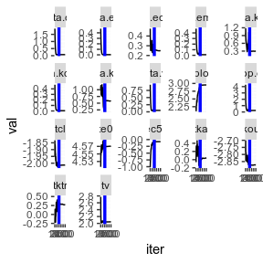

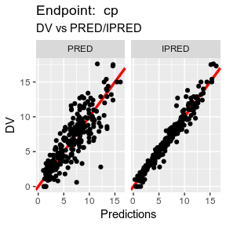

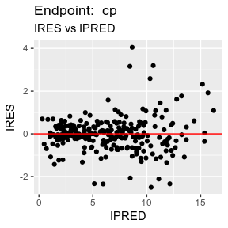

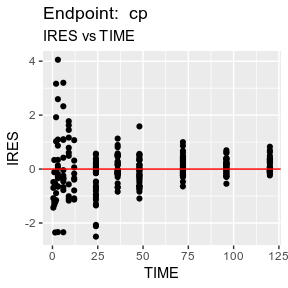

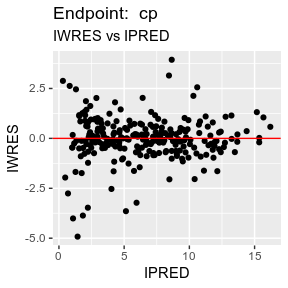

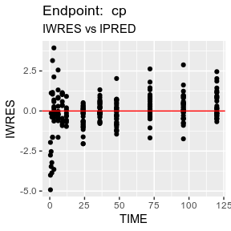

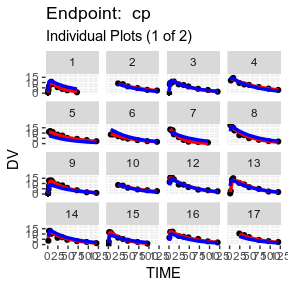

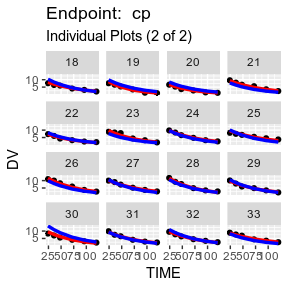

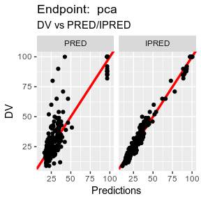

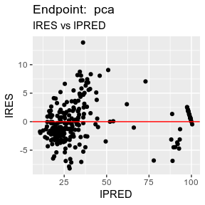

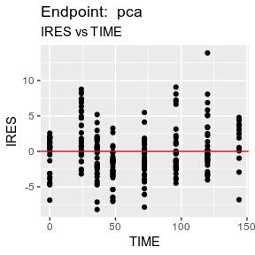

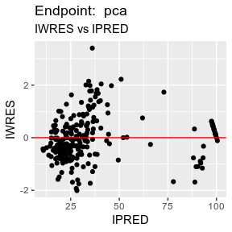

[18 more figures not shown]

```r
plot(fit.TOS);
```

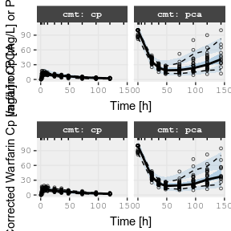

```r
library(ggplot2);
library(gridExtra);

v1 <- vpc(fit.TOS, show=list(obs_dv=T), scales="free_y") +
    ylab("Warfarin Cp [mg/L] or PCA") +
    xlab("Time [h]");

v2 <- vpc(fit.TOS, show=list(obs_dv=T), pred_corr = TRUE) +
    ylab("Prediction Corrected Warfarin Cp [mg/L] or PCA") +
    xlab("Time [h]");

grid.arrange(v1,v2);
```